# Statisctical Inference Assignment Part-1: A simulation Exercise

Benhur Tedros

February 15, 2017

## Instructions

The project consists of two parts:

#### 1. A simulation exercise.

#### 2. Basic inferential data analysis [this analysis is done in separate Rmd.file]

You will create a report to answer the questions. Given the nature of the series, ideally you’ll use knitr to create the reports and convert to a pdf.

### Part-1: Simulation Exercise

In this project you will investigate the exponential distribution in R and compare it with the Central Limit Theorem. The exponential distribution can be simulated in R with rexp(n, lambda) where lambda is the rate parameter. The mean of exponential distribution is 1/lambda and the standard deviation is also 1/lambda. Set lambda = 0.2 for all of the simulations. You will investigate the distribution of averages of 40 exponentials. Note that you will need to do a thousand simulations.

#### A) Set up the directory

```r
setwd("F:/BENHUR FOLDER/Coursera/Statistical Reference/Week 4")
library(ggplot2)
```

#### B) List the given variables in the problem and define them

```r
n<-40
lamda<-0.2
numsim<-1000
```

```r
set.seed(13579)
subset<-matrix(rexp(n*numsim,rate=lamda), numsim)
subset_mean<-apply(subset,2,mean)
subset_mean
```

```
##  [1] 5.318777 4.924133 4.853895 5.446076 4.752349 4.943597 4.972803
##  [8] 5.060417 4.824924 5.047337 4.896243 5.169162 4.891787 5.142963
## [15] 5.064407 4.637725 4.928588 5.151782 5.206764 4.625412 5.151580
## [22] 5.109839 5.311577 4.964945 4.635875 5.081767 4.975004 5.453138
## [29] 5.045792 4.768983 4.893101 4.714526 5.017694 4.965050 5.242892
## [36] 5.156068 4.875116 5.055850 5.138197 4.965177
```

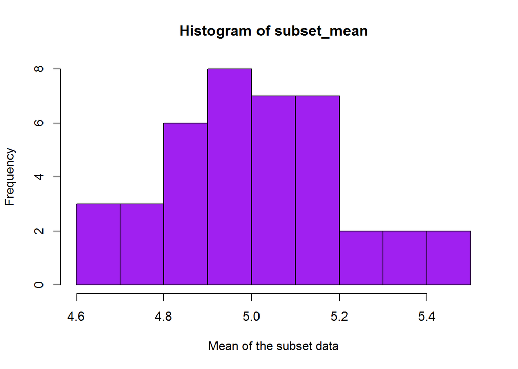

```r
hist(subset_mean,xlab="Mean of the subset data", col="purple")
```

#### Answering the questions

##### A) To show the sample mean and compare it to the theoretical mean of the distribution.

```r
Theoretical_mean<-1/lamda
Theoretical_mean
```

```
## [1] 5
```

Actual center of distribution based on simulation

```r
round(mean(subset_mean),2)
```

```
## [1] 5.01
```

##### B) To show how variable the sample is (via variance) and compare it to the theoretical variance of the distribution

```r
Theoretical_var<-(1/lamda)^2/n
Theoretical_var
```

```
## [1] 0.625
```

```r
Theoretical_sd<-(1/lamda)/sqrt(n)
Theoretical_sd
```

```
## [1] 0.7905694
```

Actual variance and standard deviation based on simulation

```r
round(var(subset_mean),2)
```

```
## [1] 0.04
```

```r
round(sd(subset_mean),2)
```

```
## [1] 0.2
```

##### C) To show that the distribution is approximately normal

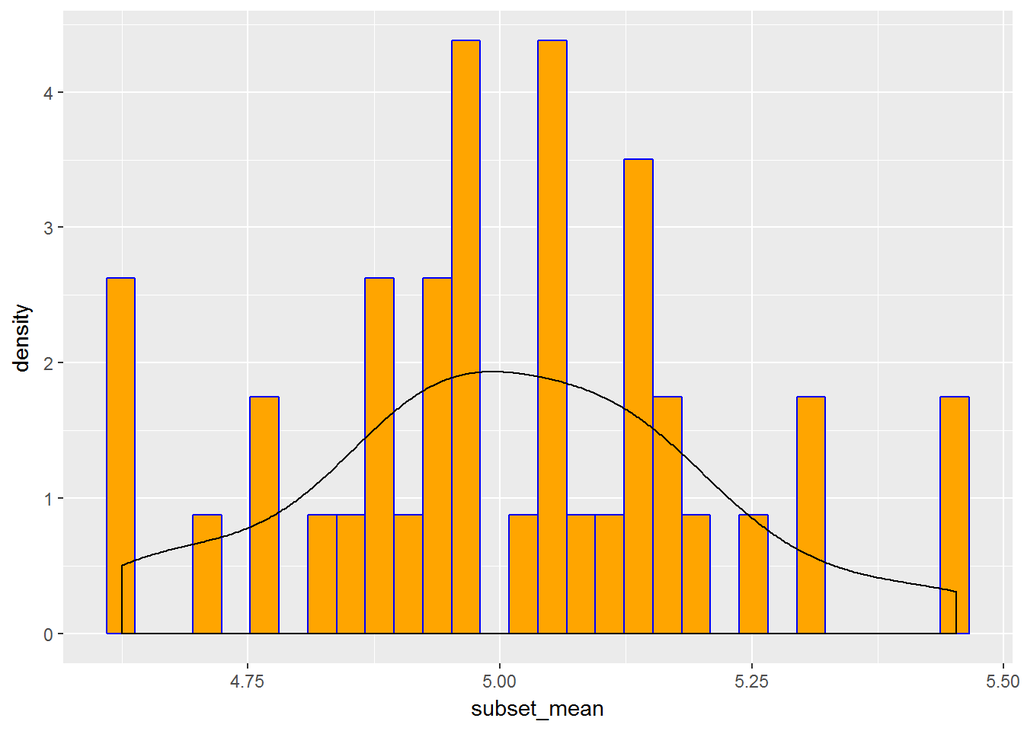

```r
data_normd<-data.frame(subset_mean)

g<-ggplot(data_normd,aes(x=subset_mean),xlab="distribution of means")

g +geom_histogram(aes(y=..density..),colour="blue",fill="orange")+geom_density()
```